# Daniel Fusca BCB420 Assignment 1

# Introduction to dataset

(Note: answers to questions in the “Interpretation” section of the assignment are distributed throughout the notebook and indicated in **bold**)

The dataset that I have selected for this assignment has GEO accession number GSE125066 and can be found at [this URL.](https://www.ncbi.nlm.nih.gov/geo/query/acc.cgi?acc=GSE125066) The dataset is named “Effect of *Toxoplasma gondii* efector TgIST on global transcriptome of human foreskin fibroblasts (HFFs) upon type I IFN activation”, and comes from the 2019 paper “*Toxoplasma gondii* effector TgIST blocks type I interferon signaling to promote infection” by Matta et al., which can be found at [this URL.](https://www.pnas.org/content/116/35/17480) This experiment collected RNA-seq data from human foreskin fibroblasts (HFFs) in 6 different experimental groups. **Cells were either left uninfected, infected with wild-type *Toxoplasma gondii* (an intracellular parasite), or infected with knockout *T. gondii* missing a gene encoding a protein (TgIST) secreted during host infection. For each of these 3 infection treatments, human cells were either treated with IFN-B (a signalling molecule used to activate host defenses) or left untreated. So, there is 1 control condition (uninfected-untreated) and 5 different experimental conditions (uninfected & IFNB-treated, wild-type infected & untreated, wild-type infected & IFNB-treated, knockout-infected & untreated, and knockout-infected & IFNB-treated). Each of these 6 conditions was done in triplicate, for a total of 18 different replicates.**

**While there are lots of interesting comparisons I can make here, the one I’m most interested in is comparing uninfected human cells (control) to human cells infected with wild-type *T. gondii* (test condition), both without any IFN-B treatment. I spent a year doing a bioinformatics research project on *T. gondii*, but the focus of that project was genetic variation between *T. gondii* strains. So, I’m interested in *T. gondii*, but I’m not sure what kind of effect it has on humans when it actually infects them. *T. gondii* is known to manipulate its host cell to help its own survival, so I was curious to see what kind of gene expression changes might occur in cells infected with the parasite. I found this dataset with gene expression data for healthy human cells and cells infected with *T. gondii*, so I thought it would be interesting to compare these conditions and see what’s different.**

# Basic setup and data downloading

My pipeline here requires 5 different R packages: BiocManager, GEOquery, edgeR, biomaRt, and ggplot2. If these packages aren’t already installed, the code here installs them:

```r
if (!requireNamespace("BiocManager", quietly = TRUE))
    install.packages("BiocManager")

if (!requireNamespace("GEOquery", quietly = TRUE))
    BiocManager::install("GEOquery")
```

```r
if (!requireNamespace("edgeR", quietly = TRUE))
    BiocManager::install("edgeR")

if (!requireNamespace("biomaRt", quietly = TRUE))
    BiocManager::install("biomaRt")

if (!requireNamespace("ggplot2", quietly = TRUE))
    install.packages("ggplot2")
```

I now need to download the actual GEO dataset. Since downloading this dataset takes a bit of time, I don’t download the dataset if it’s already been downloaded. If the data hasn’t been downloaded yet, I use GEOquery to put all of the data into a directory called “GSE125066”:

```r
if (!dir.exists("GSE125066")) {
  queryData <- GEOquery::getGEOSuppFiles("GSE125066")
}
```

I then load the downloaded gene expression data into R using read.csv:

```r
# Reading in the dataset using read.csv is kind of slow, so after reading it the
# first time, I save the result as an RData object that can be loaded on future
# runs of this notebook
if (!file.exists("GSE125066RawData.RData")) {
  rawData <- read.csv("~/GSE125066/GSE125066_Expression_Values.csv.gz", header = T,
                    check.names = F)
  save(rawData, file = "GSE125066RawData.RData")
} else {
  load("GSE125066RawData.RData")
}
```

# Initial cleaning of dataset

This dataset contains a lot of different columns:

```r
ncol(rawData)
```

```
## [1] 389
```

However, I’m only interested in the 18 columns giving raw gene expression counts for each gene (1 column for each replicate), along with the columns giving the Ensembl ID and name of each gene. So, I filtered this dataset to remove all of the columns I’m not interested in:

```r
# Column 7 of the dataset contains Ensembl gene IDs, so set these IDs to be
# the row names of this dataframe
rownames(rawData) <- rawData[, 7]

# Get only the columns containing raw gene expression data for each replicate -
# these are the columns with names ending in "Total.exon.reads"
expressionData <- rawData[, grepl("Total exon reads", colnames(rawData))]

# In addition to the row names being Ensembl gene IDs, have a separate column
# containing the gene names givin in the dataset (for comparison after mapping
# Ensembl IDs to HUGO symbols)
expressionData <- cbind(Gene = rawData[, 1], expressionData)
```

**In addition to the first column giving the name of each gene, this dataframe has 18 other columns corresponding to the 18 experimental replicates sequenced in this study:**

```r
colnames(expressionData)
```

```
##  [1] "Gene"
##  [2] "UI_UT - run_2056_s_1_withindex_sequence.txt_GAGGCGT (GE) - Total exon reads"
##  [3] "UI_UT - run_2056_s_2_withindex_sequence.txt_ACGTCTG (GE) - Total exon reads"
##  [4] "UI_UT - run_2057_s_1_withindex_sequence.txt_GGGTCAA (GE) - Total exon reads"
##  [5] "UI_IFNB - run_2056_s_1_withindex_sequence.txt_CGTCGCT (GE) - Total exon reads"
##  [6] "UI_IFNB - run_2056_s_2_withindex_sequence.txt_TGAGGTT (GE) - Total exon reads"
##  [7] "UI_IFNB - run_2057_s_1_withindex_sequence.txt_AGATACT (GE) - Total exon reads"
##  [8] "RH_UT - run_2056_s_1_withindex_sequence.txt_TTTTGTC (GE) - Total exon reads"
##  [9] "RH_UT - run_2056_s_2_withindex_sequence.txt_TTTAACT (GE) - Total exon reads"
## [10] "RH_UT - run_2057_s_1_withindex_sequence.txt_GTCGATA (GE) - Total exon reads"
## [11] "RH_IFNB - run_2056_s_1_withindex_sequence.txt_GTCTGAT (GE) - Total exon reads"
## [12] "RH_IFNB - run_2056_s_2_withindex_sequence.txt_TCAACTG (GE) - Total exon reads"
## [13] "RH_IFNB - run_2057_s_1_withindex_sequence.txt_GCTTAGA (GE) - Total exon reads"
## [14] "KO_UT - run_2056_s_1_withindex_sequence.txt_CAAGCCG (GE) - Total exon reads"
## [15] "KO_UT - run_2056_s_2_withindex_sequence.txt_ACCCACT (GE) - Total exon reads"
## [16] "KO_UT - run_2057_s_1_withindex_sequence.txt_GGTCCTC (GE) - Total exon reads"
## [17] "KO_IFNB - run_2056_s_1_withindex_sequence.txt_GCAGGGG (GE) - Total exon reads"
## [18] "KO_IFNB - run_2056_s_2_withindex_sequence.txt_CAATATC (GE) - Total exon reads"
## [19] "KO_IFNB - run_2057_s_1_withindex_sequence.txt_TGTTTGT (GE) - Total exon reads"
```

**Here, all of the replicates beginning with “UI” are human foreskin fibroblast cells that are uninfected with *T. gondii*, the replicates beginning with “RH” are infected with wild-type *T. gondii*, and the replicates beginning with “KO” are infected with mutant *T. gondii* parasites where one of the proteins secreted during infection is knocked out. Following these identifiers, the replicates named “UT” were not treated with IFN-B, and the replicates named “IFNB” were treated with IFN-B. Each of these 6 experimental combinations was done in triplicate, for a total of 18 different replicates.**

**For the purposes of my project, I only need to compare healthy control cells with a single experimental treatment. I’m interested in seeing which genes are differentially-expressed in human cells that are infected with wild-type *T. gondii*, so I want to compare uninfected, non-IFN-B treated cells (“UI_UT”) with wild-type infected, non IFN-B treated cells (“RH_UT”). When I’m doing my differential-expression analysis, I only want to look at the 6 replicates within this control and treatment group, but for the purposes of cleaning up my dataset, I think it makes sense to normalize and filter using all 18 replicates at the same time, since this data was collected, sequenced and processed with all replicates together. I can do my cleaning here using all 18 replicates, and then just filter the dataframe later to get the replicates that I’m interested in analyzing further.**

To make this processing easier, I should rename the columns that contain data for the 18 experimental replicates, so that they’re easier to read and identify:

```r
# Use rep() to define labels for all of the 18 different samples, based on their
# infection status, IFN-B treatment status, and replicate number
infections <- rep(c("UI_", "RH_", "KO_"), each = 6)
treatments <- rep(c("UT_", "IFNB_"), each = 3, length.out = 18)
replicates <- rep(c("RepA", "RepB", "RepC"), length.out = 18)


# Simplify the column names of the 18 different replicates to more easily distinguish
# different replicates within the same experimental condition
colnames(expressionData) <- c("Gene",
                              paste(infections, treatments, replicates, sep = ""))
```

The columns in my expression dataframe are now named as follows:

```r
colnames(expressionData)
```

```
##  [1] "Gene"         "UI_UT_RepA"   "UI_UT_RepB"   "UI_UT_RepC"
##  [5] "UI_IFNB_RepA" "UI_IFNB_RepB" "UI_IFNB_RepC" "RH_UT_RepA"
##  [9] "RH_UT_RepB"   "RH_UT_RepC"   "RH_IFNB_RepA" "RH_IFNB_RepB"
## [13] "RH_IFNB_RepC" "KO_UT_RepA"   "KO_UT_RepB"   "KO_UT_RepC"
## [17] "KO_IFNB_RepA" "KO_IFNB_RepB" "KO_IFNB_RepC"
```

The first column here contains the gene names included with the GEO dataset, and each of the 18 following columns gives expression data for one of the 18 experimental replicates.

Here’s a small subset of my dataset (the last 6 rows) to better show how this dataset is structured. All values here are raw gene expression counts (i.e. not normalized yet).

```r
tail(expressionData)
```

|  | Gene | UI_UT_RepA | UI_UT_RepB | UI_UT_RepC | UI_IFNB_RepA | UI_IFNB_RepB | UI_IFNB_RepC | RH_UT_RepA | RH_UT_RepB | RH_UT_RepC | RH_IFNB_RepA | RH_IFNB_RepB | RH_IFNB_RepC | KO_UT_RepA | KO_UT_RepB | KO_UT_RepC | KO_IFNB_RepA | KO_IFNB_RepB | KO_IFNB_RepC |
| --- | --- | --- | --- | --- | --- | --- | --- | --- | --- | --- | --- | --- | --- | --- | --- | --- | --- | --- | --- |
| ENSG00000203995 | ZYG11A | 37 | 41 | 40 | 32 | 17 | 42 | 78 | 67 | 151 | 95 | 114 | 104 | 92 | 72 | 89 | 61 | 64 | 68 |
| ENSG00000232242 | ZYG11AP1 | 0 | 0 | 0 | 0 | 0 | 0 | 0 | 0 | 0 | 0 | 0 | 0 | 0 | 0 | 0 | 0 | 0 | 0 |
| ENSG00000162378 | ZYG11B | 1277 | 985 | 1359 | 1014 | 800 | 787 | 741 | 400 | 1110 | 818 | 507 | 766 | 1088 | 619 | 726 | 500 | 418 | 340 |
| ENSG00000159840 | ZYX | 31604 | 34284 | 46827 | 41212 | 40690 | 62159 | 9285 | 5816 | 15756 | 13867 | 9137 | 13039 | 13779 | 10155 | 10536 | 13357 | 9554 | 13615 |
| ENSG00000074755 | ZZEF1 | 1771 | 1207 | 1822 | 1590 | 1307 | 1797 | 700 | 383 | 990 | 738 | 443 | 680 | 911 | 450 | 562 | 633 | 335 | 522 |
| ENSG00000036549 | ZZZ3 | 672 | 512 | 786 | 795 | 662 | 798 | 357 | 226 | 633 | 443 | 293 | 429 | 494 | 364 | 369 | 302 | 254 | 285 |

Before I do any filtering or normalization, it would be good to know how many genes are in this initial dataset:

```r
# How many different Ensembl IDs are in the dataset?
nrow(expressionData)
```

```
## [1] 57773
```

```r
# How many unique gene names are in the dataset?
length(unique(expressionData$Gene))
```

```
## [1] 57773
```

```r
# So, every row in this dataset has a unique name in the "Gene" column:
nrow(expressionData) == length(unique(expressionData$Gene))
```

```
## [1] TRUE
```

```r
# However, these gene names aren't all entirely unique. For example, the first
# 7 genes in this dataset are all called "5S_rRNA" but with a different number
# appended to the end
head(expressionData$Gene, 7)
```

```
## [1] 5S_rRNA_1 5S_rRNA_2 5S_rRNA_3 5S_rRNA_4 5S_rRNA_5 5S_rRNA_6 5S_rRNA_7
## 57773 Levels: 5S_rRNA_1 5S_rRNA_2 5S_rRNA_3 5S_rRNA_4 5S_rRNA_5 ... ZZZ3
```

Knowing that every row contains a unique Ensembl ID (and so likely a unique gene, although I’ll have to check HUGO symbols to confirm this), I can next ask: does every gene in my dataset have some sort of expression value for each of the 18 replicates, or are there any missing or invalid values? I’m expecting all of my count data to be non-negative integers, so to confirm this I checked for any NA or negative values:

```r
# Are any values in the expression dataset NA?
sum(is.na(expressionData[ , 2:19]))
```

```
## [1] 0
```

```r
# Are all 18 columns in the expression dataset non-negative integers?
sum(apply(expressionData[, 2:19], 2, is.integer))
```

```
## [1] 18
```

```r
sum(expressionData[ , 2:19] < 0)
```

```
## [1] 0
```

So, each of the 18 columns of this dataset that contain expression values only contain non-negative integer values, and none of them contain missing data in the form of NA values. This means there are no obvious technical errors that would require me to remove any rows from my dataset.

Now that I know there are no major issues with my expression data, I can start looking at how these expression values are distributed. For example, how many total counted reads are in each of the 18 replicates (i.e. what does each column sum to)?

```r
colSums(expressionData[ , 2:19])
```

```
##   UI_UT_RepA   UI_UT_RepB   UI_UT_RepC UI_IFNB_RepA UI_IFNB_RepB
##     24461080     20966080     28705672     27577279     23792524
## UI_IFNB_RepC   RH_UT_RepA   RH_UT_RepB   RH_UT_RepC RH_IFNB_RepA
##     32867480     11772165      8123030     19802728     15977353
## RH_IFNB_RepB RH_IFNB_RepC   KO_UT_RepA   KO_UT_RepB   KO_UT_RepC
##     10672859     15577006     16064831     11300686     11720194
## KO_IFNB_RepA KO_IFNB_RepB KO_IFNB_RepC
##     14145548     10278698     13383264
```

So, there’s a lot of variation in the sequencing depth for each of these replicates (although these counts don’t include sequenced reads that weren’t mapped onto genes and used for counting). The total RNAs counted in each replicate range from 8,123,030 to 32,867,480, so it would be a good idea to normalize my counts for sequencing depth (e.g. using Counts Per Million).

Next, for each of the 18 replicates, as an overview I got the minimum, first quartile, median, mean, third quartile, and maximum expression values using the summary() function:

```r
summary(expressionData[ , 2:19])
```

```
##    UI_UT_RepA         UI_UT_RepB         UI_UT_RepC
##  Min.   :     0.0   Min.   :     0.0   Min.   :      0.0
##  1st Qu.:     0.0   1st Qu.:     0.0   1st Qu.:      0.0
##  Median :     0.0   Median :     0.0   Median :      0.0
##  Mean   :   423.4   Mean   :   362.9   Mean   :    496.9
##  3rd Qu.:    14.0   3rd Qu.:     8.0   3rd Qu.:     14.0
##  Max.   :817488.0   Max.   :727198.0   Max.   :1012278.0
##   UI_IFNB_RepA        UI_IFNB_RepB       UI_IFNB_RepC
##  Min.   :      0.0   Min.   :     0.0   Min.   :      0.0
##  1st Qu.:      0.0   1st Qu.:     0.0   1st Qu.:      0.0
##  Median :      0.0   Median :     0.0   Median :      0.0
##  Mean   :    477.3   Mean   :   411.8   Mean   :    568.9
##  3rd Qu.:     14.0   3rd Qu.:     9.0   3rd Qu.:     15.0
##  Max.   :1075524.0   Max.   :881861.0   Max.   :1395987.0
##    RH_UT_RepA         RH_UT_RepB         RH_UT_RepC
##  Min.   :     0.0   Min.   :     0.0   Min.   :     0.0
##  1st Qu.:     0.0   1st Qu.:     0.0   1st Qu.:     0.0
##  Median :     0.0   Median :     0.0   Median :     0.0
##  Mean   :   203.8   Mean   :   140.6   Mean   :   342.8
##  3rd Qu.:     9.0   3rd Qu.:     6.0   3rd Qu.:    14.0
##  Max.   :204164.0   Max.   :111001.0   Max.   :294298.0
##   RH_IFNB_RepA       RH_IFNB_RepB       RH_IFNB_RepC
##  Min.   :     0.0   Min.   :     0.0   Min.   :     0.0
##  1st Qu.:     0.0   1st Qu.:     0.0   1st Qu.:     0.0
##  Median :     0.0   Median :     0.0   Median :     0.0
##  Mean   :   276.6   Mean   :   184.7   Mean   :   269.6
##  3rd Qu.:    13.0   3rd Qu.:     7.0   3rd Qu.:    11.0
##  Max.   :299365.0   Max.   :158955.0   Max.   :243404.0
##    KO_UT_RepA         KO_UT_RepB         KO_UT_RepC
##  Min.   :     0.0   Min.   :     0.0   Min.   :     0.0
##  1st Qu.:     0.0   1st Qu.:     0.0   1st Qu.:     0.0
##  Median :     0.0   Median :     0.0   Median :     0.0
##  Mean   :   278.1   Mean   :   195.6   Mean   :   202.9
##  3rd Qu.:    12.0   3rd Qu.:     7.0   3rd Qu.:     8.0
##  Max.   :292825.0   Max.   :167356.0   Max.   :147652.0
##   KO_IFNB_RepA       KO_IFNB_RepB       KO_IFNB_RepC
##  Min.   :     0.0   Min.   :     0.0   Min.   :     0.0
##  1st Qu.:     0.0   1st Qu.:     0.0   1st Qu.:     0.0
##  Median :     0.0   Median :     0.0   Median :     0.0
##  Mean   :   244.8   Mean   :   177.9   Mean   :   231.7
##  3rd Qu.:     9.0   3rd Qu.:     7.0   3rd Qu.:     9.0
##  Max.   :288850.0   Max.   :130810.0   Max.   :180241.0
```

One conclusion to draw from these statistics is that all of the replicates have a median expression value of 0, meaning that at least half of the genes in each replicate did not have any detected expression at all.

As part of cleaning up this dataset, I should remove genes that have very low expression. As a first pass, I can look at how many genes had no detected expression in any of the replicates, as these are obviously genes that I would want to filter out.

```r
sum(rowSums(expressionData[, 2:19]) == 0)
```

```
## [1] 28605
```

```r
# What percentage of the entire dataset is that?
100 * (sum(rowSums(expressionData[, 2:19]) == 0) / nrow(expressionData))
```

```
## [1] 49.51275
```

For my project, I’m only really interested in the “UI_UT” data columns and the “RH_UT” data columns. How many genes had 0 detected expression in all 6 of these columns?

```r
sum(rowSums(expressionData[ , c(2, 3, 4, 8, 9, 10)]) == 0)
```

```
## [1] 31573
```

```r
# What percentage of the entire dataset is this?
100 * (sum(rowSums(expressionData[ , c(2, 3, 4, 8, 9, 10)]) == 0) / nrow(expressionData))
```

```
## [1] 54.6501
```

So, almost half the listed genes in this dataset had 0 detected expression across all 18 of the replicates I’m using here. Considering just the 6 replicates corresponding to the control and treament conditions I want to actually analyze, this percentage jumps to over 54%. Thus, there’s definitely a need for me to filter out lowly-expressed genes.

Each experimental condition has 3 replicates, so edgeR recommends only keeping genes expressed to at least 1 read per million in at least 3 of the replicates. The following code filters out all of the genes that do not meet this criteria:

```r
# Create a dataframe where the raw counts from expressionData are converted to
# counts per million, using edgeR's cpm function. These lines are based off of
# code shown in Lecture 4 of BCB420
countsPerMillion <- edgeR::cpm(expressionData[ , 2:19])
expressionData_filtered <- expressionData[rowSums(countsPerMillion >= 1) >= 3, ]
```

How many genes are we left with after filtering out lowly-expressed genes?

```r
nrow(expressionData_filtered)
```

```
## [1] 14822
```

```r
# How many genes were filtered out due to being too lowly-expressed?
nrow(expressionData) - nrow(expressionData_filtered)
```

```
## [1] 42951
```

```r
# What percentage of the initial dataset is left after filtering out low counts?
100 * (nrow(expressionData_filtered) / nrow(expressionData))
```

```
## [1] 25.65558
```

**So, after filtering out 42,951 lowly-expressed genes, I’m left with 14,822 genes, which is around a quarter of the 57,773 genes that were present in the initial GEO dataset. Aside from these 42,951 “outliers” that I removed, I’m not going to exclude any other genes on the basis of their gene expression data. I don’t have any reason to suspect that any of these observations were the result of measurement error - all of the data here are non-negative integers, as expected of counts, and the distribution of expression values looked pretty normal to me.**

For each of the 18 replicates, get the minimum, first quartile, median, mean, third quartile, and maximum values of the remaining genes:

```r
summary(expressionData_filtered[ , 2:19])
```

```
##    UI_UT_RepA       UI_UT_RepB       UI_UT_RepC       UI_IFNB_RepA
##  Min.   :     0   Min.   :     0   Min.   :      0   Min.   :      0
##  1st Qu.:    99   1st Qu.:    73   1st Qu.:    109   1st Qu.:     95
##  Median :   421   Median :   329   Median :    477   Median :    407
##  Mean   :  1648   Mean   :  1413   Mean   :   1934   Mean   :   1858
##  3rd Qu.:  1224   3rd Qu.:  1001   3rd Qu.:   1389   3rd Qu.:   1281
##  Max.   :817488   Max.   :727198   Max.   :1012278   Max.   :1075524
##   UI_IFNB_RepB     UI_IFNB_RepC       RH_UT_RepA       RH_UT_RepB
##  Min.   :     0   Min.   :      0   Min.   :     0   Min.   :     0.0
##  1st Qu.:    74   1st Qu.:    102   1st Qu.:    58   1st Qu.:    38.0
##  Median :   335   Median :    449   Median :   227   Median :   148.0
##  Mean   :  1604   Mean   :   2215   Mean   :   793   Mean   :   547.2
##  3rd Qu.:  1071   3rd Qu.:   1413   3rd Qu.:   634   3rd Qu.:   424.0
##  Max.   :881861   Max.   :1395987   Max.   :204164   Max.   :111001.0
##    RH_UT_RepC      RH_IFNB_RepA     RH_IFNB_RepB       RH_IFNB_RepC
##  Min.   :     0   Min.   :     0   Min.   :     0.0   Min.   :     0.0
##  1st Qu.:    98   1st Qu.:    79   1st Qu.:    50.0   1st Qu.:    78.0
##  Median :   389   Median :   294   Median :   193.0   Median :   299.5
##  Mean   :  1334   Mean   :  1076   Mean   :   719.1   Mean   :  1049.4
##  3rd Qu.:  1079   3rd Qu.:   834   3rd Qu.:   556.0   3rd Qu.:   824.0
##  Max.   :294298   Max.   :299365   Max.   :158955.0   Max.   :243404.0
##    KO_UT_RepA       KO_UT_RepB         KO_UT_RepC
##  Min.   :     0   Min.   :     0.0   Min.   :     0.0
##  1st Qu.:    76   1st Qu.:    46.0   1st Qu.:    56.0
##  Median :   297   Median :   196.0   Median :   219.0
##  Mean   :  1082   Mean   :   761.5   Mean   :   789.6
##  3rd Qu.:   852   3rd Qu.:   594.0   3rd Qu.:   642.0
##  Max.   :292825   Max.   :167356.0   Max.   :147652.0
##   KO_IFNB_RepA        KO_IFNB_RepB       KO_IFNB_RepC
##  Min.   :     0.00   Min.   :     0.0   Min.   :     0.0
##  1st Qu.:    57.25   1st Qu.:    40.0   1st Qu.:    50.0
##  Median :   226.00   Median :   165.0   Median :   203.5
##  Mean   :   953.15   Mean   :   692.6   Mean   :   901.8
##  3rd Qu.:   683.75   3rd Qu.:   519.0   3rd Qu.:   639.0
##  Max.   :288850.00   Max.   :130810.0   Max.   :180241.0
```

The medians and first quartiles of all 18 replicates are now well above 0, so it seems that the filtering here was able to successfully remove genes that were expressed at very low levels. However, the distribution of expression data appears to differ pretty substantially between the 18 replicates - the median values range from 148 to 477. Ideally, I want the distributions of expression values to be pretty similar to each other, so this is a sign that I should normalize my data. Before I do any normalization though, I should assign all of these genes HUGO symbols.

# Identifier mapping

For my final dataset, I want all of the rows of my dataframe (i.e. every different gene) to be named after the HUGO symbol for that gene, rather than its Ensembl ID as they are currently. Since I have a unique Ensembl ID for all of these genes, I can perform some identifier mapping to map these Ensembl IDs onto HUGO symbols, and then assign HUGO symbols to genes. To do this identifier mapping, I can use the biomaRt package to query Ensembl for the HUGO symbols corresponding to my Ensembl IDs.

This code is based off of the code presented in Lecture 4 of BCB420 for querying Biomart using the biomaRt package. Since retrieving this data from Ensembl can be slow, we only actually retrieve it the first time this code is run, after which we save it as an RData file. If we’ve run this code once already, we can just load the identifier mapping we saved previously:

```r
# Code to query Biomart and obtain HUGO symbols based off of code presented in
# lecture. When I initially tried setting up my mart object, I kept getting errors
# because the Ensembl web server was experiencing some server issues, so here I
# specified a different host (http://useast.ensembl.org) without server issues.
# This is based on code from the Bioconductor support forum found here:
# https://support.bioconductor.org/p/122843/#122887
if (!file.exists("GSE125066HUGONames.RData")) {
  humanEnsembl <- biomaRt::useEnsembl("ensembl", "hsapiens_gene_ensembl",
                                      host = 'http://useast.ensembl.org')
  HUGONameConversions <- biomaRt::getBM(attributes = c("ensembl_gene_id","hgnc_symbol"),
                                      filters = c("ensembl_gene_id"),
                                      values = rownames(expressionData_filtered),
                                      mart = humanEnsembl)
  save(HUGONameConversions, file = "GSE125066HUGONames.RData")
} else {
  load("GSE125066HUGONames.RData")
}
```

I now have a dataframe with 2 columns: the first contains Ensembl IDs, and the second contains the HUGO symbol corresponding to that ID. First, I asked: how many rows are in the resulting Ensembl-HUGO identifier mapping?

```r
nrow(HUGONameConversions)
```

```
## [1] 14472
```

Did any Ensembl IDs map onto more than 1 HUGO ID?

```r
length(unique(HUGONameConversions$ensembl_gene_id))
```

```
## [1] 14471
```

```r
length(unique(HUGONameConversions$ensembl_gene_id)) == nrow(HUGONameConversions)
```

```
## [1] FALSE
```

The Ensembl-HUGO mapping dataframe contains 14,472 Ensembl IDs in total, but only 14,471 unique Ensembl IDs. It looks like a single Ensembl ID mapped onto two different HUGO IDs (all other Ensembl IDs mapped to at most 1 HUGO symbol). To find which ID this is, I used the following command to count how many times each Ensembl ID appears in the Ensembl-HUGO mapping, and return the Ensembl IDs that appear more than once.

```r
table(HUGONameConversions$ensembl_gene_id)[table(HUGONameConversions$ensembl_gene_id) != 1]
```

```
## ENSG00000230417
##               2
```

So, ENSG00000230417 mapped onto 2 different HUGO symbols:

```r
HUGONameConversions[HUGONameConversions$ensembl_gene_id == "ENSG00000230417", ]
```

|  | ensembl_gene_id | hgnc_symbol |
| --- | --- | --- |
| 6660 | ENSG00000230417 | LINC00595 |
| 6661 | ENSG00000230417 | LINC00856 |

Since my dataset of expression values from GEO has a column giving the name of each gene (in addition to its Ensembl ID), I can look up this Ensembl ID in my expression dataset to see what name was given to it:

```r
expressionData_filtered["ENSG00000230417", "Gene"]
```

```
## [1] LINC00856
## 57773 Levels: 5S_rRNA_1 5S_rRNA_2 5S_rRNA_3 5S_rRNA_4 5S_rRNA_5 ... ZZZ3
```

So, the Ensembl ID “ENSG00000230417” mapped onto both “LINC00595” and “LINC00856”, but in the expression dataset it is only named as “LINC00856”. Also, none of the genes in the expression dataset were given the name “LINC00595”:

```r
"LINC00595" %in% expressionData_filtered$Gene
```

```
## [1] FALSE
```

Since I can only assign 1 name to the row containing ENSG00000230417, I’m going to break the tie between its 2 mapped HUGO symbols by naming it LINC00856, as this is what it was already called in the GEO dataset. This is so that I’m consistent with my approach for giving names to Ensembl IDs that didn’t map to HUGO symbols, since in that case my only option is going to be to use the gene names already present in the GEO dataset.

Since I’m not using the mapping between ENSG00000230417 and LINC00595, I removed it from the Ensembl-HUGO mapping dataframe:

```r
HUGONameConversions <- HUGONameConversions[HUGONameConversions$hgnc_symbol != "LINC00595", ]

# How many rows are left in the resulting Ensembl-HUGO dataframe?
nrow(HUGONameConversions)
```

```
## [1] 14471
```

Next, I looked at how many rows in this dataframe did NOT map onto an empty HUGO symbol. This number gives the total number of unique Ensembl IDs in our filtered expression dataset that were able to map to a HUGO symbol (since after the above removal of LINC00595, no Ensembl ID maps to more than 1 HUGO ID)

```r
# How many Ensembl IDs in our filtered dataset were mapped onto a HUGO symbol?
sum(HUGONameConversions$hgnc_symbol != "")
```

```
## [1] 13815
```

```r
# How many Ensembl IDs in our filtered dataset WEREN'T mapped onto a HUGO symbol?
# (This includes those not present in the mapping dataframe, plus those in the
# mapping dataframe that mapped onto "")
nrow(expressionData_filtered) - sum(HUGONameConversions$hgnc_symbol != "")
```

```
## [1] 1007
```

```r
# What percentage of the Ensembl IDs in our filtered dataset were able to map
# onto a HUGO symbol?
100 * (sum(HUGONameConversions$hgnc_symbol != "") / nrow(expressionData_filtered))
```

```
## [1] 93.20605
```

Over 90% of the genes in my filtered dataset (13,815) were able to map onto a HUGO ID, which is pretty good. **However, there were 1007 Ensembl IDs (and therefore rows of expression values) that did NOT map onto any HUGO symbols (note that this mapping only used the 14,822 genes that passed my filter for lowly-expressed genes - when considering the full set of 57,773 genes initially in this dataset, it is likely that more than 1007 Ensembl IDs would have failed to map). For these 1007 genes, I’m going to have to set their HUGO symbol as the name that was given to them in the original GEO dataset.**

I then looked at another issue that could have arisen during mapping: did multiple different Ensembl IDs map to the same HUGO symbol? The code here gets all of the HUGO symbols that mapped with more than 1 Ensembl ID:

```r
table(HUGONameConversions$hgnc_symbol)[table(HUGONameConversions$hgnc_symbol) != 1]
```

```
##
##        TUBB7P
##    656      2
```

There appears to be 2 different values that appear more than one time in the “HUGO Symbol” column of the mapping. There’s an empty string that appears 656 times - these are Ensembl IDs that were unable to map onto any HUGO ID. The only actual HUGO ID that appears in this mapping more than 1 time is TUBB7P, which 2 different Ensembl IDs mapped onto:

```r
HUGONameConversions[HUGONameConversions$hgnc_symbol == "TUBB7P", ]
```

|  | ensembl_gene_id | hgnc_symbol |
| --- | --- | --- |
| 13414 | ENSG00000173876 | TUBB7P |
| 13514 | ENSG00000251297 | TUBB7P |

It looks like both ENSG00000173876 and ENSG00000251297 mapped onto the same HUGO symbol, although these are the only genes to do so. I’m going to deal with this issue after I give HUGO symbols to the Ensembl IDs that didn’t map onto anything, since this process might create additional duplications.

I then added all of my HUGO symbols to my dataframe of gene expression values, based on the Ensembl ID that they mapped to:

```r
# Merge the expression dataframe and the HUGO symbol mapping, using Ensembl IDs
# to match between dataframes. These IDs are the row names of the expression dataset
# and the first column of the HUGO symbol mapping
HUGO_expressionData_filtered <- merge(expressionData_filtered, HUGONameConversions,
                                      by.x = "row.names", by.y = "ensembl_gene_id",
                                      all.x = T)

# Ensembl IDs not included in the Ensembl-HUGO mapping will have their HUGO symbol
# set to NA - set all of these to "" to match the other 656 Ensembl IDs that
# didn't map properly
HUGO_expressionData_filtered$hgnc_symbol[is.na(HUGO_expressionData_filtered$hgnc_symbol)] <- ""

# How many genes have a HUGO symbol that matches the gene name that was initially
# given to it in the GEO dataset?
sum(HUGO_expressionData_filtered$hgnc_symbol == HUGO_expressionData_filtered$Gene)
```

```
## [1] 12762
```

```r
# What percentage of the entire dataset is this?
100 * sum(HUGO_expressionData_filtered$hgnc_symbol ==
            HUGO_expressionData_filtered$Gene) / nrow(HUGO_expressionData_filtered)
```

```
## [1] 86.10174
```

Almost all (around 86%) of the genes in the filtered expression dataset had names that already matched the HUGO symbols I just assigned them. Out of the remaining 14% of genes, some genes will have different names because they didn’t map onto any HUGO symbol at all - as previously shown, there are 1007 of these genes. For these 1007 genes, I think it makes the most sense to give them the name that was already present in the GEO dataset. As shown above, the names in the dataset almost all matched the HUGO symbols I just assigned, so I’m reasonably confident that the names in the expression dataset right now are pretty accurate HUGO symbols. If I want to give names to the genes that didn’t map onto HUGO symbols, my best course of action is probably to fill in these missing values using the names already present in the dataset. I don’t really have an easy way of getting other names for these genes, so this seems like the best course of action.

The code below gets all of the genes that didn’t map to HUGO symbols, and assigns their HUGO symbol as the name already given in the GEO dataset:

```r
# Convert HUGO symbols to character to avoid issues with using factors
HUGO_expressionData_filtered$hgnc_symbol <- as.character(HUGO_expressionData_filtered$hgnc_symbol)

HUGO_expressionData_filtered$hgnc_symbol[HUGO_expressionData_filtered$hgnc_symbol == ""] <-
  as.character(HUGO_expressionData_filtered$Gene[HUGO_expressionData_filtered$hgnc_symbol == ""])
```

The code above got rid of all of the genes with a HUGO symbol of "":

```r
sum(HUGO_expressionData_filtered$hgnc_symbol == "")
```

```
## [1] 0
```

After filling in that missing information, how many genes still have HUGO symbols that don’t match the name given in the initial GEO dataset?

```r
sum(HUGO_expressionData_filtered$hgnc_symbol != HUGO_expressionData_filtered$Gene)
```

```
## [1] 1053
```

```r
# What percentage of the entire dataset is this?
100 * sum(HUGO_expressionData_filtered$hgnc_symbol !=
            HUGO_expressionData_filtered$Gene) / nrow(HUGO_expressionData_filtered)
```

```
## [1] 7.104304
```

These 1053 genes are likely those that have outdated annotations compared to what’s currently on Ensembl, so in these cases I think it makes the most sense to ignore the names that were initially in the GEO dataset and use the HUGO symbols I just mapped for them.

Before I finish with my identifier mapping and move on to normalization, I still need to address the genes where 2 different Ensembl IDs mapped onto the same HUGO symbol. I previously identified the TUBB7P gene as being problematic in this regard, but filling in missing HUGO IDs using the names in the GEO dataset created an additional 8 cases of this issue:

```r
table(HUGO_expressionData_filtered$hgnc_symbol)[table(HUGO_expressionData_filtered$hgnc_symbol) != 1]
```

```
##
##     ACBD6     AGAP9 C17orf100     CBWD6      MEG8    NBPF20     RPS17
##         2         2         2         2         2         2         2
##    TUBB7P    ZCCHC3
##         2         2
```

**There are now 9 HUGO symbols (ACBD6, AGAP9, C17orf100, CBWD6, MEG8, NBPF20, RPS17, TUBB7P, and ZCCHC3) that each map onto 2 different Ensembl IDs:**

```r
duplicates <- c("ACBD6", "AGAP9", "C17orf100", "CBWD6", "MEG8", "NBPF20", "RPS17",
                "TUBB7P", "ZCCHC3")

HUGO_expressionData_filtered[HUGO_expressionData_filtered$hgnc_symbol %in% duplicates,
                             c("Row.names", "Gene", "hgnc_symbol")]
```

|  | Row.names | Gene | hgnc_symbol |
| --- | --- | --- | --- |
| 5609 | ENSG00000135847 | ACBD6 | ACBD6 |
| 8328 | ENSG00000162825 | NBPF8 | NBPF20 |
| 10153 | ENSG00000173876 | TUBB8 | TUBB7P |
| 10596 | ENSG00000177764 | ZCCHC3 | ZCCHC3 |
| 11074 | ENSG00000182774 | RPS17L | RPS17 |
| 11327 | ENSG00000184779 | RPS17 | RPS17 |
| 12264 | ENSG00000198035 | AGAP9 | AGAP9 |
| 12534 | ENSG00000203832 | NBPF20 | NBPF20 |
| 12565 | ENSG00000204172 | AGAP10 | AGAP9 |
| 12669 | ENSG00000204790 | CBWD6 | CBWD6 |

[output cut: 8 more lines]

**Thus, right now in my dataset there are 18 rows of expression values that belong to only 9 different genes, based on HUGO symbols. I think the fairest way to resolve these conflicts is, for each replicate, to add together the counts for each pair of identical HUGO symbols. The only other option would be to completely ignore one of the “duplicate” genes in each pair, but the issue with that is I don’t really have a good way of deciding which gene within each pair to ignore, and which to keep. So, in order to not ignore any reads that appear to map onto genes, I’m going to combine the counts within each pair by adding them up, for each of the 18 replicates.**

```r
# Define a function to take in 2 Ensembl IDs and a gene expression dataset, add
# together the 2 rows corresponding to these IDs, and then remove 1 of the rows
addAndRemoveDuplicates <- function(ID1, ID2, expressionData) {
  expressionData[expressionData$Row.names == ID1, 3:20] <-
  expressionData[expressionData$Row.names == ID1, 3:20] +
  expressionData[expressionData$Row.names == ID2, 3:20]

  expressionData <- expressionData[expressionData$Row.names != ID2, ]

  return(expressionData)
}


# Call this function on the 9 pairs of Ensembl IDs that map to duplicate HUGO symbols
HUGO_expressionData_filtered <- addAndRemoveDuplicates("ENSG00000135847",
                                                       "ENSG00000230124",
                                                       HUGO_expressionData_filtered)
HUGO_expressionData_filtered <- addAndRemoveDuplicates("ENSG00000198035",
                                                       "ENSG00000204172",
                                                       HUGO_expressionData_filtered)
HUGO_expressionData_filtered <- addAndRemoveDuplicates("ENSG00000212734",
                                                       "ENSG00000256806",
                                                       HUGO_expressionData_filtered)
HUGO_expressionData_filtered <- addAndRemoveDuplicates("ENSG00000204790",
                                                       "ENSG00000215126",
                                                       HUGO_expressionData_filtered)
HUGO_expressionData_filtered <- addAndRemoveDuplicates("ENSG00000225746",
                                                       "ENSG00000258399",
                                                       HUGO_expressionData_filtered)
HUGO_expressionData_filtered <- addAndRemoveDuplicates("ENSG00000162825",
                                                       "ENSG00000203832",
                                                       HUGO_expressionData_filtered)
HUGO_expressionData_filtered <- addAndRemoveDuplicates("ENSG00000182774",
                                                       "ENSG00000184779",
                                                       HUGO_expressionData_filtered)
HUGO_expressionData_filtered <- addAndRemoveDuplicates("ENSG00000173876",
                                                       "ENSG00000251297",
                                                       HUGO_expressionData_filtered)
HUGO_expressionData_filtered <- addAndRemoveDuplicates("ENSG00000177764",
                                                       "ENSG00000247315",
                                                       HUGO_expressionData_filtered)
```

How many genes are we now left with in our expression dataset after merging these 9 pairs of rows?

```r
nrow(HUGO_expressionData_filtered)
```

```
## [1] 14813
```

This is 9 fewer genes than I had before (14,822), which is as expected since I should have only removed 9 rows from my dataframe.

After merging those 9 pairs of rows, every gene in this dataset now has a unique HUGO symbol:

```r
length(unique(HUGO_expressionData_filtered$hgnc_symbol))
```

```
## [1] 14813
```

```r
length(unique(HUGO_expressionData_filtered$hgnc_symbol)) == nrow(HUGO_expressionData_filtered)
```

```
## [1] TRUE
```

Now, I can set the row names of my expression dataframe to be HUGO symbols instead of Ensembl IDs, and then remove all of the columns from my dataframe that aren’t the 18 columns of expression values:

```r
# Set the row names to be HUGO symbols
rownames(HUGO_expressionData_filtered) <- HUGO_expressionData_filtered$hgnc_symbol

# Remove all of the columns except those containing gene expression information
HUGO_expressionData_filtered <- HUGO_expressionData_filtered[ , 3:20]
```

If I did everything correctly, I should now have a dataframe with 14,813 rows (one for each gene) and 18 columns (1 for each replicate):

```r
dim(HUGO_expressionData_filtered)
```

```
## [1] 14813    18
```

# Normalization

My final major step here is to normalize my expression dataset. As I found previously, the replicates here vary quite a bit in the depth they were sequenced to. To account for this, I can normalize my data by taking the log2 of the Count Per Million (CPM) for each expression value, using Trimmed Mean of M-values (TMM) normalization. This should correct for the technical variation present in this data.

The code here performs the log-CPM and TMM normalization on my data. For comparison purposes, I calculated log-CPM values both with and without TMM normalization. This code is based off of the normalization code presented in Lecture 4 of BCB420.

```r
# Save the dataframe of non-normalized expression data as an edgeR object, assigning
# each of the replicates to 1 of 6 experimental groups
edgeRExpressionData <- edgeR::DGEList(HUGO_expressionData_filtered,
            group = rep(c("UI_UT", "UI_IFNB", "RH_UT", "RH_IFNB", "KO_UT", "KO_IFNB"), each = 3))

# Calculate normalization factors for TMM
normalizedExpressionData <- edgeR::calcNormFactors(edgeRExpressionData)

# Estimate dispersion values for the normalized count data. To make comparisons
# later, also estimate dispersion values for the non-normalized data, to compare
# the effects of normalization
normalizedExpressionData <- edgeR::estimateDisp(normalizedExpressionData)
```

```
## Design matrix not provided. Switch to the classic mode.
```

```r
edgeRExpressionData <- edgeR::estimateDisp(edgeRExpressionData)
```

```
## Design matrix not provided. Switch to the classic mode.
```

```r
# Take the log2 of the CPM for both the TMM-normalized and non-normalized count
# data
logCPMExpressionData <- edgeR::cpm(edgeRExpressionData, log = T)
logCPMNormalizedExpressionData <- edgeR::cpm(normalizedExpressionData, log = T)
```

I now have an expression dataset that’s been normalized to log-CPM units with a TMM normalization. Here are some summary statistics for the distribution of expression values within each replicate:

```r
summary(logCPMNormalizedExpressionData)
```

```
##    UI_UT_RepA       UI_UT_RepB       UI_UT_RepC      UI_IFNB_RepA
##  Min.   :-3.114   Min.   :-3.114   Min.   :-3.114   Min.   :-3.114
##  1st Qu.: 2.037   1st Qu.: 1.930   1st Qu.: 1.998   1st Qu.: 1.992
##  Median : 4.094   Median : 4.072   Median : 4.096   Median : 4.043
##  Mean   : 3.793   Mean   : 3.733   Mean   : 3.767   Mean   : 3.818
##  3rd Qu.: 5.627   3rd Qu.: 5.668   3rd Qu.: 5.632   3rd Qu.: 5.691
##  Max.   :15.007   Max.   :15.168   Max.   :15.137   Max.   :15.401
##   UI_IFNB_RepB     UI_IFNB_RepC      RH_UT_RepA       RH_UT_RepB
##  Min.   :-3.114   Min.   :-3.114   Min.   :-3.114   Min.   :-3.114
##  1st Qu.: 1.899   1st Qu.: 1.934   1st Qu.: 2.192   1st Qu.: 2.158
##  Median : 4.047   Median : 4.041   Median : 4.133   Median : 4.091
##  Mean   : 3.783   Mean   : 3.802   Mean   : 3.906   Mean   : 3.864
##  3rd Qu.: 5.712   3rd Qu.: 5.686   3rd Qu.: 5.609   3rd Qu.: 5.603
##  Max.   :15.394   Max.   :15.630   Max.   :13.936   Max.   :13.632
##    RH_UT_RepC      RH_IFNB_RepA     RH_IFNB_RepB     RH_IFNB_RepC
##  Min.   :-3.114   Min.   :-3.114   Min.   :-3.114   Min.   :-3.114
##  1st Qu.: 2.175   1st Qu.: 2.274   1st Qu.: 2.197   1st Qu.: 2.240
##  Median : 4.136   Median : 4.145   Median : 4.118   Median : 4.157
##  Mean   : 3.886   Mean   : 3.983   Mean   : 3.905   Mean   : 3.930
##  3rd Qu.: 5.602   3rd Qu.: 5.643   3rd Qu.: 5.641   3rd Qu.: 5.609
##  Max.   :13.690   Max.   :14.127   Max.   :13.794   Max.   :13.812
##    KO_UT_RepA       KO_UT_RepB       KO_UT_RepC      KO_IFNB_RepA
##  Min.   :-3.114   Min.   :-3.114   Min.   :-3.114   Min.   :-3.114
##  1st Qu.: 2.175   1st Qu.: 2.014   1st Qu.: 2.161   1st Qu.: 2.166
##  Median : 4.118   Median : 4.080   Median : 4.100   Median : 4.101
##  Mean   : 3.915   Mean   : 3.853   Mean   : 3.888   Mean   : 3.954
##  3rd Qu.: 5.627   3rd Qu.: 5.668   3rd Qu.: 5.645   3rd Qu.: 5.694
##  Max.   :14.049   Max.   :13.801   Max.   :13.487   Max.   :14.411
##   KO_IFNB_RepB     KO_IFNB_RepC
##  Min.   :-3.114   Min.   :-3.114
##  1st Qu.: 2.066   1st Qu.: 2.067
##  Median : 4.080   Median : 4.065
##  Mean   : 3.932   Mean   : 3.917
##  3rd Qu.: 5.727   3rd Qu.: 5.708
##  Max.   :13.701   Max.   :13.842
```

From these statistics, I can conclude that after log-CPM and TMM normalization, the distributions of expression values are pretty similar between all 18 replicates.

To get a better view of how expression values are distributed within my 18 replicates after normalization, I can make boxplots. Here, I plot my expression data both with and without TMM normalization, to see the effect of TMM normalization. Labels for replicates are colored based on their combination of infection status (either uninfected, wild-type infected, or knockout infected) and IFN-B treatment (either untreated or treated).

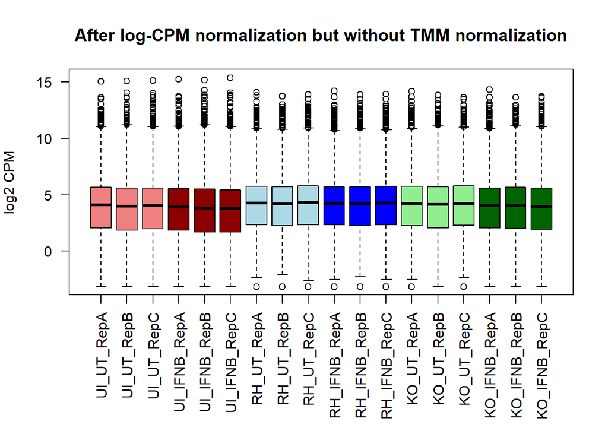

```r
# Adjust the margins so that the x-axis labels don't get cut off
par(mar=c(8,4,4,2))

# Draw the plots
colorsForPlotting <- rep(c("lightcoral",
    "darkred", "lightblue", "blue", "lightgreen", "darkgreen"), each = 3)
boxplot(logCPMExpressionData, las = 2, ylab = "log2 CPM",
        main = "After log-CPM normalization but without TMM normalization",
        col = colorsForPlotting)
```

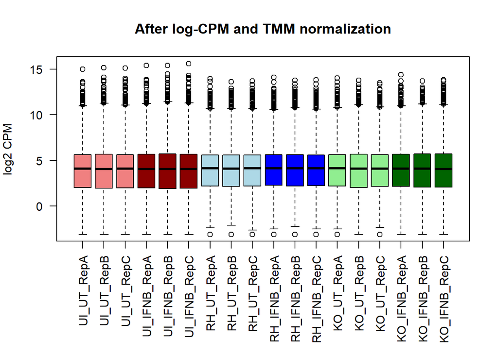

```r
boxplot(logCPMNormalizedExpressionData, las = 2, ylab = "log2 CPM",
        main = "After log-CPM and TMM normalization",
        col = colorsForPlotting)
```

```r
# Reset the margins back to their default values
par(mar=c(5,4,4,2))
```

TMM normalization appears to have made the distributions of all 18 replicates slightly more similar to each other, although the effect isn’t that large.

As another view of this data, I can make density plots of my expression data, again both with and without TMM normalization:

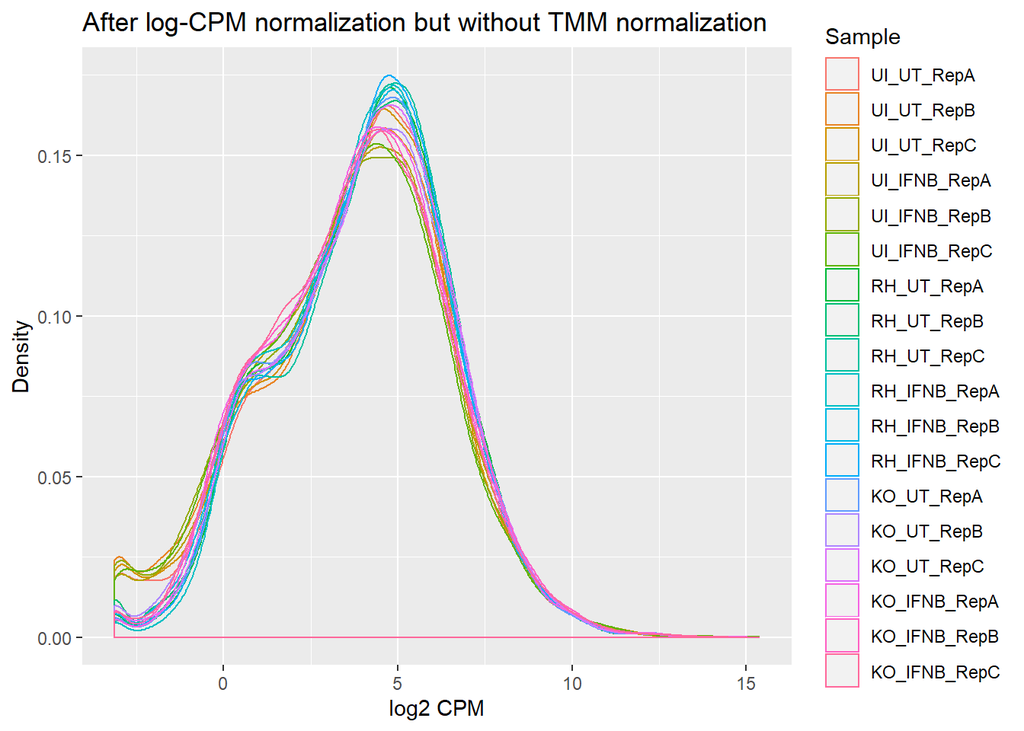

```r
# Define a function to take in a dataset of log-CPM expression values, and plot
# the density of expression values
makeDensityPlot <- function(expressionData, plotTitle) {

  dataToPlot <- data.frame(Sample = colnames(expressionData)[1], Expression =
                             expressionData[ , 1])

  for (i in 2:18) {
    dataToPlot <- rbind(dataToPlot, data.frame(Sample = colnames(expressionData)[i], Expression =
                             expressionData[ , i]))
  }

  ggplot2::ggplot(dataToPlot, ggplot2::aes(x = Expression, color = Sample)) +
    ggplot2::geom_density() + ggplot2::labs(title = plotTitle, x = "log2 CPM",
                                            y = "Density")

}

# Draw density plots for the non-TMM normalized and TMM normalized data, using
# the above function
makeDensityPlot(logCPMExpressionData,
                plotTitle = "After log-CPM normalization but without TMM normalization")
```

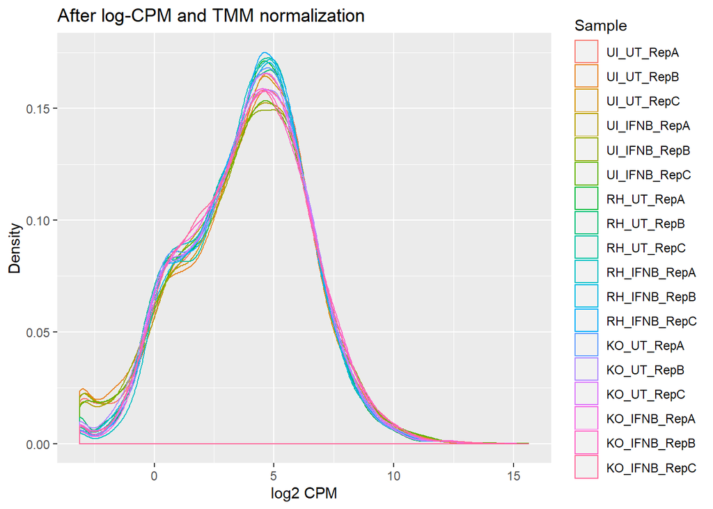

```r
makeDensityPlot(logCPMNormalizedExpressionData,
                plotTitle = "After log-CPM and TMM normalization")
```

Again, it looks like TMM normalization made all of the distributions slightly more similar to each other, but not by much.

To see how similar the expression profiles of my replicates are to each other, I can make MDS plots using their expression data. Ideally, all 3 replicates within an experimental treatment should cluster together, and the 6 groups of experimental treatments should be fairly separated from each other. To look at this while also examining the effects of normalization, I made MDS plots for the raw count data, the count data normalized by log-CPM but not TMM, and the count data normalized by both log-CPM and TMM.

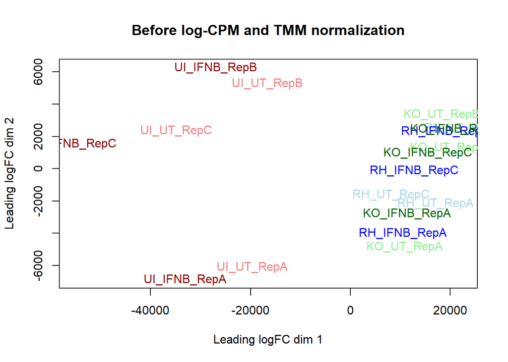

```r
limma::plotMDS(HUGO_expressionData_filtered, col = colorsForPlotting, main =
                 "Before log-CPM and TMM normalization")
```

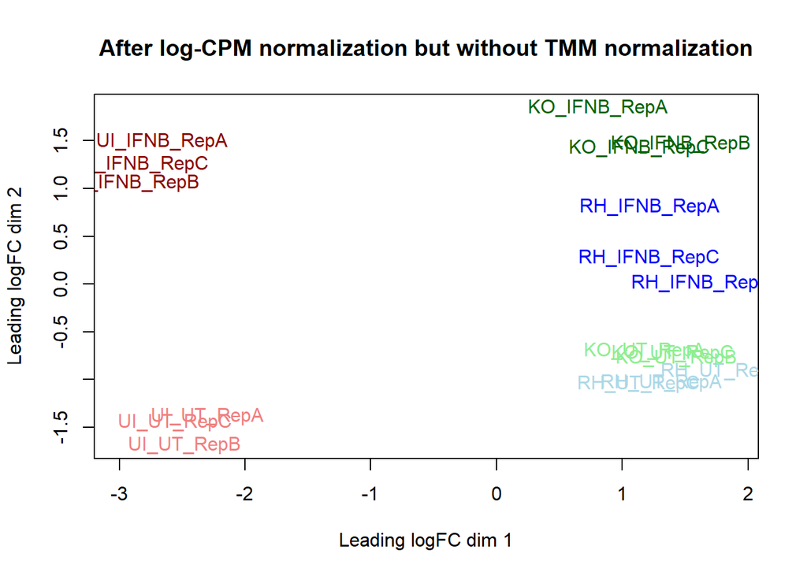

```r
limma::plotMDS(logCPMExpressionData, col = colorsForPlotting,
               main = "After log-CPM normalization but without TMM normalization")
```

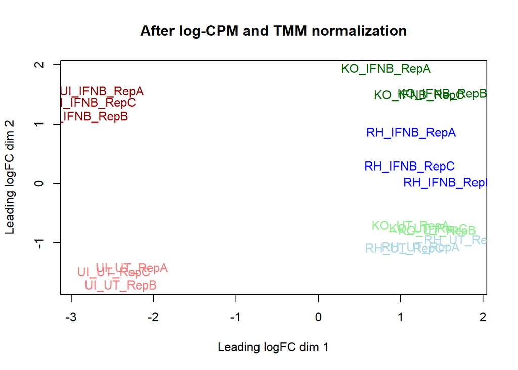

```r
limma::plotMDS(logCPMNormalizedExpressionData, col = colorsForPlotting, main =
                 "After log-CPM and TMM normalization")
```

To better understand the variation present within my expression dataset, I can make dispersion plots to see how much expression varies between different genes. I made these plots using my data from before and after TMM normalization, to see if this normalization has any effect.

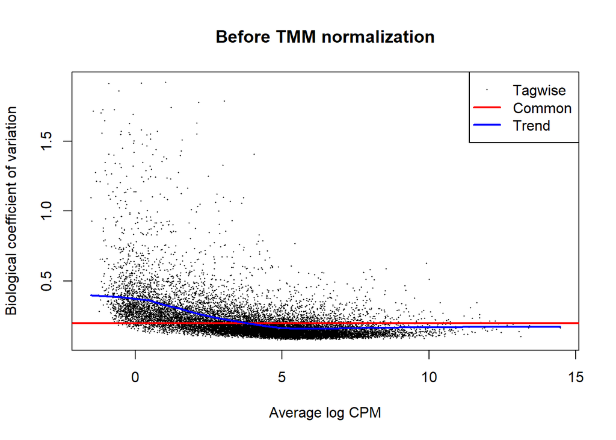

```r
# Plot tagwise dispersions with and without TMM normalization
edgeR::plotBCV(edgeRExpressionData, main = "Before TMM normalization")
```

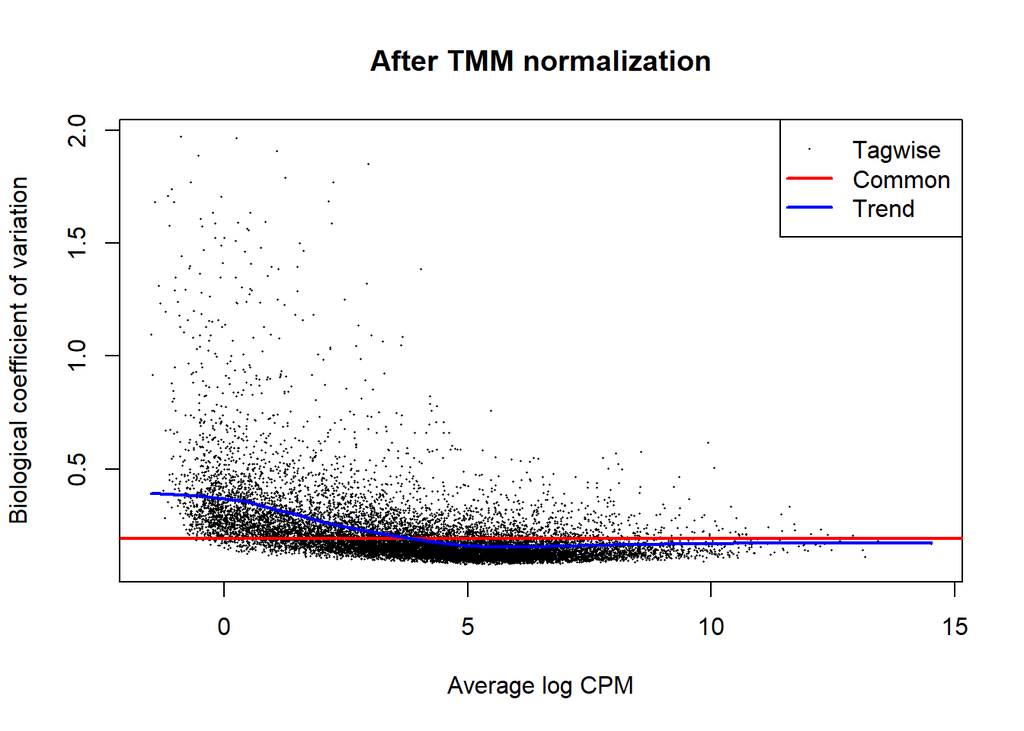

```r
edgeR::plotBCV(normalizedExpressionData, main = "After TMM normalization")
```

These plots look pretty normal - as expected, dispersion tends to decrease as average expression increases. Based on these plots, it doesn’t look like TMM normalization has much of an effect on the distribution of tagwise dispersions.

# Output final dataset

Now that all of my cleaning and normalization are done, I can export my finalized dataframe. Again, here are the dimensions of this dataframe:

```r
dim(logCPMNormalizedExpressionData)
```

```
## [1] 14813    18
```

Here’s what the first 6 rows of this dataset look like, to give a representation of how it’s structured:

```r
head(logCPMNormalizedExpressionData)
```

```
##          UI_UT_RepA UI_UT_RepB UI_UT_RepC UI_IFNB_RepA UI_IFNB_RepB
## TSPAN6     3.792151   3.213486   3.728097     3.518470     3.122940
## DPM1       4.712662   4.713156   4.793922     4.014893     4.157446
## SCYL3      2.613111   2.175867   2.840798     3.056894     2.579299
## C1orf112   1.773581   1.948842   1.567280     1.361406     1.535795
## CFH        5.862165   4.796965   5.278425     6.850066     6.242643
## FUCA2      5.690473   6.165490   6.060852     5.674769     6.236114
##          UI_IFNB_RepC RH_UT_RepA RH_UT_RepB RH_UT_RepC RH_IFNB_RepA
## TSPAN6       3.218058   3.623227   3.692401   3.503423     3.774197
## DPM1         3.697551   4.170228   4.315122   4.252736     3.755167
## SCYL3        2.818295   2.373670   2.001784   2.007856     2.426193
## C1orf112     1.505775   2.476757   2.730322   2.678423     2.143561
## CFH          6.320448   5.719881   5.530343   5.591072     6.227661
## FUCA2        6.200877   5.848472   6.281509   6.194031     6.088883
##          RH_IFNB_RepB RH_IFNB_RepC KO_UT_RepA KO_UT_RepB KO_UT_RepC
## TSPAN6       3.747513     3.410301   3.753504   3.335251   3.500321
## DPM1         4.245793     4.108410   4.179344   4.558656   4.644201
## SCYL3        1.697488     2.409943   2.474242   2.043861   2.257759
## C1orf112     2.947048     2.409943   2.174666   2.238911   2.083384
## CFH          5.619938     5.888848   6.273044   5.288599   5.559921
## FUCA2        6.631307     6.409613   5.910319   6.438886   6.357916
##          KO_IFNB_RepA KO_IFNB_RepB KO_IFNB_RepC
## TSPAN6       3.867199     3.460529     3.220733
## DPM1         3.632995     4.131237     3.546645
## SCYL3        2.878575     1.518123     1.789162
## C1orf112     2.066018     2.066128     1.789162
## CFH          6.851531     6.610936     5.953214
## FUCA2        6.046434     6.440472     6.356145
```

For future use with the rest of my project, I should export this expression dataframe onto my computer. First, I saved this dataset as an RData object named “logCPMNormalizedExpressionData.RData”

```r
save(logCPMNormalizedExpressionData, file = "logCPMNormalizedExpressionData.RData")
```

Whenever I need this dataframe, I can just load it into R using the load() function.

Additionally, I also saved this same dataset as a CSV file, in case I want it in a format that I can actually read or use outside of R:

```r
write.csv(logCPMNormalizedExpressionData, file = "logCPMNormalizedExpressionData.csv",
          row.names = T, quote = F)
```

To summarize, this notebook outputs 2 different objects for future use: a dataframe of cleaned and normalized gene counts as an RData file (logCPMNormalizedExpressionData.RData), and the exact same dataframe as a CSV file (logCPMNormalizedExpressionData.csv).